```r
library(dplyr)
```

```r
library(fansi)
library(ggplot2)
library(tidyr)
library(datasets)
library(methods)
library(readxl)
library(autoplotly)
library(fpp2)
library(dplyr)
library(timeSeries)
library(stats)
library(nycflights13)
library(ggsci)
library(ggsci)
library(ggpubr)
ANOVA_2_ <- read_excel("~/Downloads/ANOVA (2).xlsx")
```

Trabalho Recuperação EPS7000 Eduardo F. Silva 25 de novembro de 2018 Aluno: Lucca

Gráficos Crie um boxplot (pacote ggplot2) que apresente os atrasos na chegada (arr_delay) para cada mês do ano. É possível fazer alguma consideração significativa verificando os outliers?

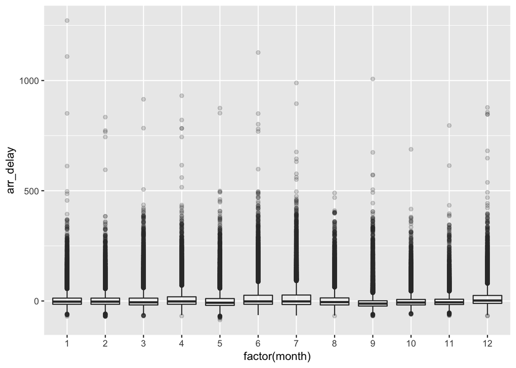

```r
library(nycflights13)
voos <- flights

boxplotNYC<- ggplot(data = flights, mapping = aes(x = factor(month), y = arr_delay)) +
  geom_boxplot(alpha= 0.2)

boxplotNYC
```

R: Podemos observar aqui que em média todos os boxplots estão pareados, sem que haja uma certa variação considerável deles. Analisando os Outliers vemos que os mesmos estão separados de forma uniforme durante o decorrer dos meses e, por ser um banco de daodos grande(300K+ data records), existe uma quantidade considerável de outliers na nossa amostra. Mesmo assim, os outliers ainda não impactam de forma grosseira na nossa análise pois apesar de visíveis, ainda assim não influenciam diretamente. ——————————————————————————————————– Teste de hipóteses Os programas de formação em gestão são frequentemente planejados para melhorar habilidades e, assim, aumentar a produtividade. Suponha que um psicólogo da empresa administra um conjunto de exames para cada um dos dez supervisores antes do programa de treinamento e, em seguida, administra exames semelhantes no final do programa. Os exames destinam-se a medir as competências de supervisão, com maior pontuação indicando maior habilidade. Os resultados dos testes são mostrados na tabela. Os dados indicam que há evidência de que o treinamento foi bem sucedido, melhorando a performance dos supervisores? Teste esta hipótese usando um nível de significância de 0.10. (t= -4.02, rejeita Ho)( Encontre e interprete o p-valor do teste.

R: Aqui tratamos de um teste t-student pareado. Vamos usar a nossa função t.test para descobrir se há ou não evidências para rejeitar a Nossa Ho.

```r
antes = c(63,93,84,72,65,72,91,84,71,80)
depois = c(78,92,91,80,69,85,99,82,81,87)
teste<- t.test(antes,depois,paired = TRUE,alternative = c("less"))
teste
```

```
##
##  Paired t-test
##
## data:  antes and depois
## t = -4.0219, df = 9, p-value = 0.001505
## alternative hypothesis: true difference in means is less than 0
## 95 percent confidence interval:
##       -Inf -3.755085
## sample estimates:
## mean of the differences
##                    -6.9
```

Ao executar nossos comandos, podemos ver que o nosso teste de hipótese obteve o resultado de -4.0219 o que significa que Ho(não melhora dos treinamentos) pode ser rejeitada.

Poder do teste Refaça o exercício do Poder do Teste (Aula 3 de teste de hipóteses, slide 11), para p=05 e compare com o resultado/gráfico considerando a hipótese alternativa como p > 0.5.

```r
n = 30
p = 0.5
sd = sqrt((p * (1 - p)/n))

c2<-qnorm(0.950,p,sd)
p_hat_seq = seq(0, 1, 0.01)
power_30<-1-pnorm(c2,p_hat_seq,sd)

power_30
```

```
##   [1] 5.315748e-13 1.170175e-12 2.545963e-12 5.474288e-12 1.163314e-11
##   [6] 2.443201e-11 5.071232e-11 1.040320e-10 2.109219e-10 4.226506e-10
##  [11] 8.370471e-10 1.638441e-09 3.169775e-09 6.061033e-09 1.145487e-08
##  [16] 2.139751e-08 3.950674e-08 7.209726e-08 1.300503e-07 2.318755e-07
##  [21] 4.086531e-07 7.118978e-07 1.225885e-06 2.086692e-06 3.511159e-06
##  [26] 5.840283e-06 9.603217e-06 1.561017e-05 2.508508e-05 3.985200e-05
##  [31] 6.259241e-05 9.719434e-05 1.492174e-04 2.265006e-04 3.399412e-04
##  [36] 5.044710e-04 7.402554e-04 1.074126e-03 1.541255e-03 2.187039e-03
##  [41] 3.069168e-03 4.259781e-03 5.847606e-03 7.939928e-03 1.066418e-02
##  [46] 1.416896e-02 1.862417e-02 2.422004e-02 3.116488e-02 3.968116e-02
##  [51] 5.000000e-02 6.235396e-02 7.696815e-02 9.405009e-02 1.137786e-01
##  [56] 1.362921e-01 1.616776e-01 1.899605e-01 2.210958e-01 2.549630e-01
##  [61] 2.913626e-01 3.300178e-01 3.705793e-01 4.126338e-01 4.557168e-01
##  [66] 4.993274e-01 5.429461e-01 5.860529e-01 6.281462e-01 6.687601e-01
##  [71] 7.074796e-01 7.439532e-01 7.779016e-01 8.091233e-01 8.374950e-01
##  [76] 8.629697e-01 8.855706e-01 9.053829e-01 9.225439e-01 9.372310e-01
##  [81] 9.496513e-01 9.600293e-01 9.685976e-01 9.755874e-01 9.812216e-01
##  [86] 9.857090e-01 9.892404e-01 9.919864e-01 9.940961e-01 9.956978e-01
##  [91] 9.968992e-01 9.977897e-01 9.984418e-01 9.989137e-01 9.992511e-01
##  [96] 9.994895e-01 9.996558e-01 9.997706e-01 9.998488e-01 9.999015e-01
## [101] 9.999365e-01
```

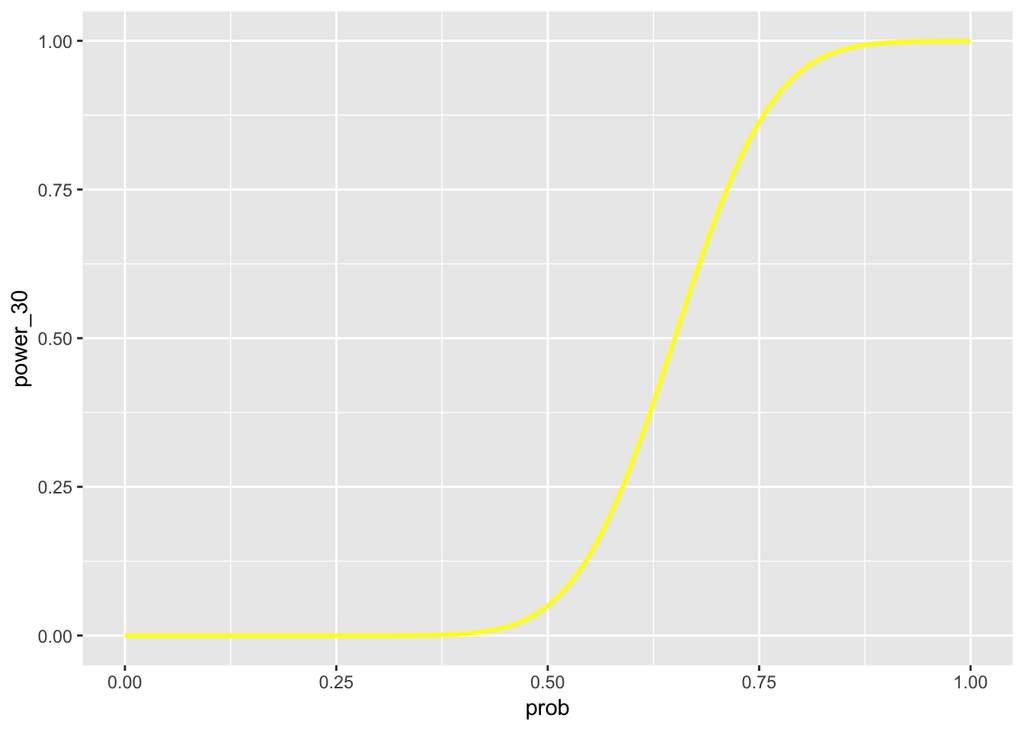

```r
library(ggplot2)
df <- data.frame(prob = p_hat_seq, power_30=power_30)
ggplot(df)+
  geom_line(aes(x=prob, y=power_30),size=1, color = "yellow")
```

ANOVA Estudantes receberam diferentes tratamentos antes de estudarem para uma prova. Alguns receberam remédio para memória, outro grupo placebo (farinha) e o terceiro nada recebeu. Execute o teste one-way ANOVA para testar a hipótese de que os tratamentos possuem efeitos diferentes.

A tabela pode ser vizualizada abaixo:

```r
dados <- ANOVA_2_
set.seed(1234)
dplyr::sample_n(dados, 12)
```

```
## # A tibble: 12 x 2
##    Desempenho Grupo
##         <dbl> <chr>
##  1         77 remedio
##  2         57 Placebo
##  3         50 Placebo
##  4         17 Nada
##  5         63 Placebo
##  6         43 Placebo
##  7         70 remedio
##  8         30 Nada
##  9         97 remedio
## 10         90 remedio
## 11         37 Placebo
## 12         83 remedio
```

```r
levels(dados$Desempenho)
```

```r
levels(dados$Grupo)
```

```r
dados$Grupo <- ordered(dados$Grupo,
                                                levels = c("remedio", "Nada", "Placebo"))
dados$Grupo
```

```
##  [1] remedio remedio remedio remedio remedio Placebo Placebo Placebo
##  [9] Placebo Placebo Nada    Nada    Nada    Nada    Nada
## Levels: remedio < Nada < Placebo
```

```r
group_by(dados, Grupo) %>%
  summarise(
    count = n(),
    mean = mean(Desempenho, na.rm = TRUE),
    sd = sd(Desempenho, na.rm = TRUE)
  )
```

```
## # A tibble: 3 x 4
##   Grupo   count  mean    sd
##   <ord>   <int> <dbl> <dbl>
## 1 remedio     5  83.4  10.6
## 2 Nada        5  16.6  10.6
## 3 Placebo     5  50    10.4
```

```r
anovatest <- aov(Desempenho~Grupo, data = dados)
summary(anovatest)
```

```
##             Df Sum Sq Mean Sq F value   Pr(>F)
## Grupo        2  11156    5578   50.16 1.49e-06 ***
## Residuals   12   1334     111
## ---
## Signif. codes:  0 '***' 0.001 '**' 0.01 '*' 0.05 '.' 0.1 ' ' 1
```

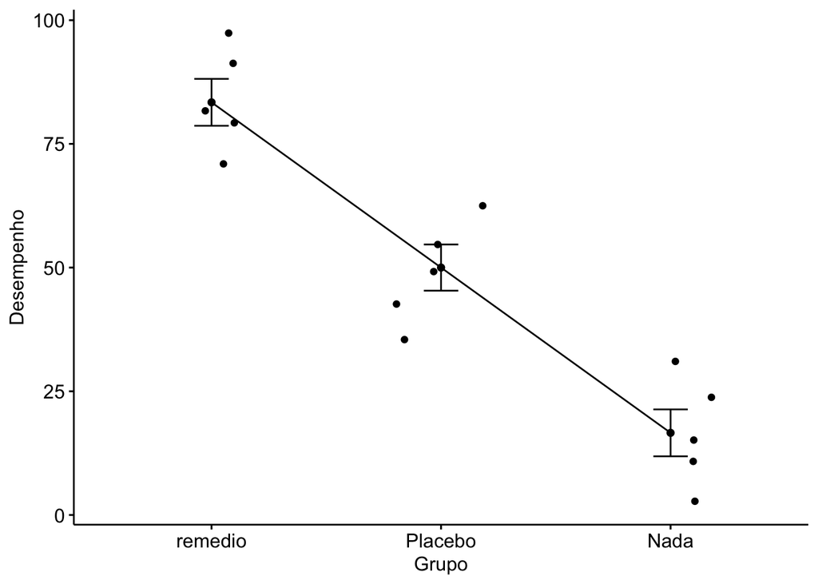

```r
testeANOVA<- ggline(dados, x = "Grupo", y = "Desempenho",
       add = c("mean_se", "jitter"),
       order = c("remedio", "Placebo", "Nada"),
       ylab = "Desempenho", xlab = "Grupo")
testeANOVA
```

Vamos baixar a nossos dados e transformar em uma variável do tipo ts:

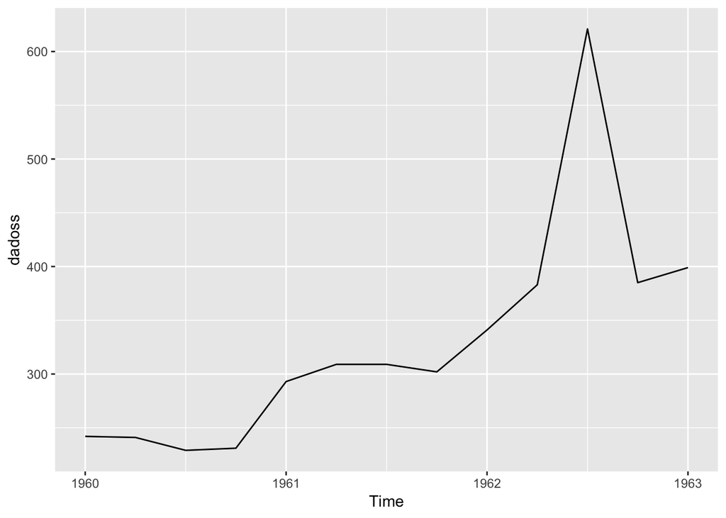

```r
Dados_ETS <- read_excel("~/Downloads/Dados.ETS.xlsx")
dadoss <- ts(Dados_ETS$Q1, frequency = 4, start = c(1960,1))
autoplot(dadoss)
```

```r
dadoss
```

```
##      Qtr1 Qtr2 Qtr3 Qtr4
## 1960  242  241  229  231
## 1961  293  309  309  302
## 1962  341  383  621  385
## 1963  399
```

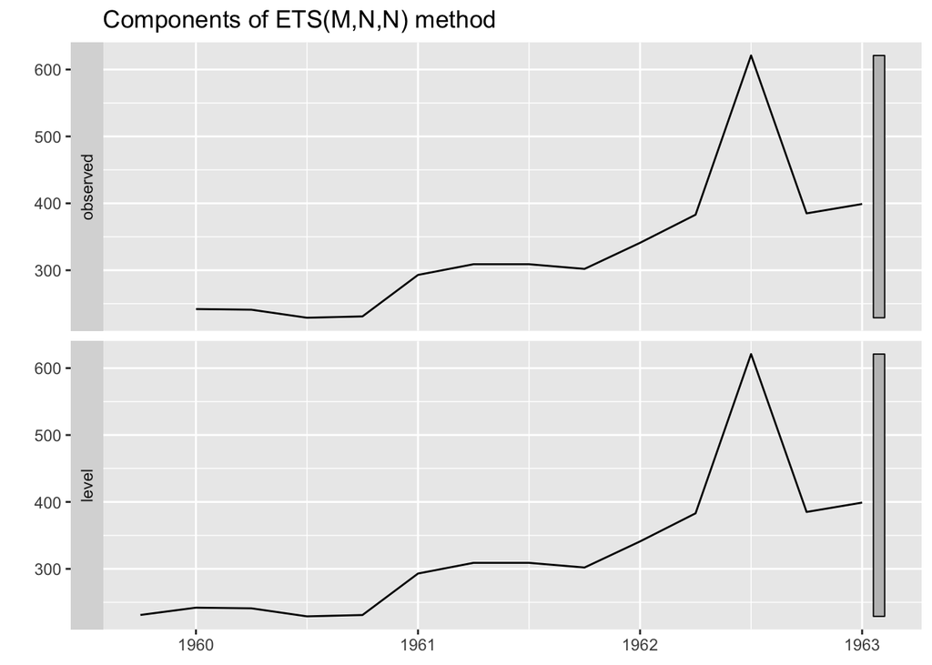

```r
ets <- ets(dadoss)
autoplot(ets)
```

```r
accuracy(ets)
```

```
##                    ME     RMSE      MAE      MPE     MAPE      MASE
## Training set 12.91617 96.16822 52.29695 2.051982 12.70815 0.5570089
##                    ACF1
## Training set -0.4152147
```